# Agrupamiento de los barrios

Daniel Ceballos Monsalve

Daniel Hoyos Gonzalez

Andrés Felipe Mejía Quintero

Doris Steffania Obando Gonzalez

Santiago Zuluaga Ayala

```r
library(dplyr)
library(lubridate)
library(ggplot2)
```

## Preparación

### Base de datos

```r
# Base de datos accidentes
df_acc <- read.csv("Accidentalidad_Medellin3.csv")
```

### Definiciones

- Variable accidente: Cuenta el total de accidentes durante los cuatro años.
- Variable grave: Tiene en cuenta aquellos accidentes que resultaron en gravedad como herido o con fatalidad.

## Categorización de accidentalidad por No. de accidentes

Se categoriza de la siguiente manera:

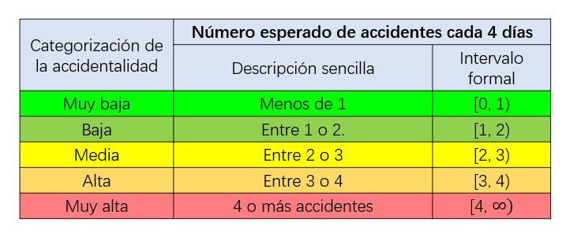

Categorización por No. de accidentes

```r
df <- df_acc %>%
        group_by(barrio) %>%
          summarise(accidentes = n(),
                    graves = length(gravedad[gravedad == "MUERTO" | gravedad == "HERIDO"]),
                    tasa_graves = graves/accidentes,
                    cat_accidentalidad = case_when(accidentes < 365 ~ "Muy Baja",
                                               accidentes >= 365 & accidentes < 730 ~ "Baja",
                                               accidentes >= 730 & accidentes < 1095 ~ "Media",
                                               accidentes >= 1095 & accidentes < 1461 ~ "Alta",
                                               accidentes >= 1461 ~ "Muy Alta"))
```

## Categorización utilizando la gravedad de los accidentes

Se calculó tasa_graves como $\dfrac{graves}{accidentes}$

Ahora, se categoriza a cada barrio por su tasa de gravedad (No. de accidentes con herido o fallecido / No. de accidentes).

- Tasa de gravedad < 0.5 -> Gravedad baja
- Tasa de gravedad entre [0.5, 0.75) -> Gravedad media
- Tasa de gravedad >= 0.75 -> Gravedad alta.

```r
# Categorización
df <- df %>% mutate(cat_tasa_graves = case_when(tasa_graves < 0.5 ~ "Baja",
                                                tasa_graves >= 0.5 & tasa_graves <0.75 ~ "Media",
                                                tasa_graves >= 0.75 ~ "Alta") )

unique(df$cat_tasa_graves)
```

```
## [1] "Media" "Alta"  "Baja"
```

```r
head(df)
```

```
## # A tibble: 6 x 6
##   barrio         accidentes graves tasa_graves cat_accidentalid~ cat_tasa_graves
##   <chr>               <int>  <int>       <dbl> <chr>             <chr>
## 1 Aguas Frias            78     58       0.744 Muy Baja          Media
## 2 Aldea Pablo VI         63     53       0.841 Muy Baja          Alta
## 3 Alejandria            370     96       0.259 Baja              Baja
## 4 Alejandro Ech~        676    494       0.731 Baja              Media
## 5 Alfonso Lopez         962    654       0.680 Media             Media
## 6 Altamira              657    432       0.658 Baja              Media
```

Se categorzó para obtener tres categorías.

## Visualización espacial de la división del espacio

Con las dos variables con las que se categorizó previamente, se realiza el agrupamiento. Inicialmente realizamos una visualización para detectar posibles grupos.

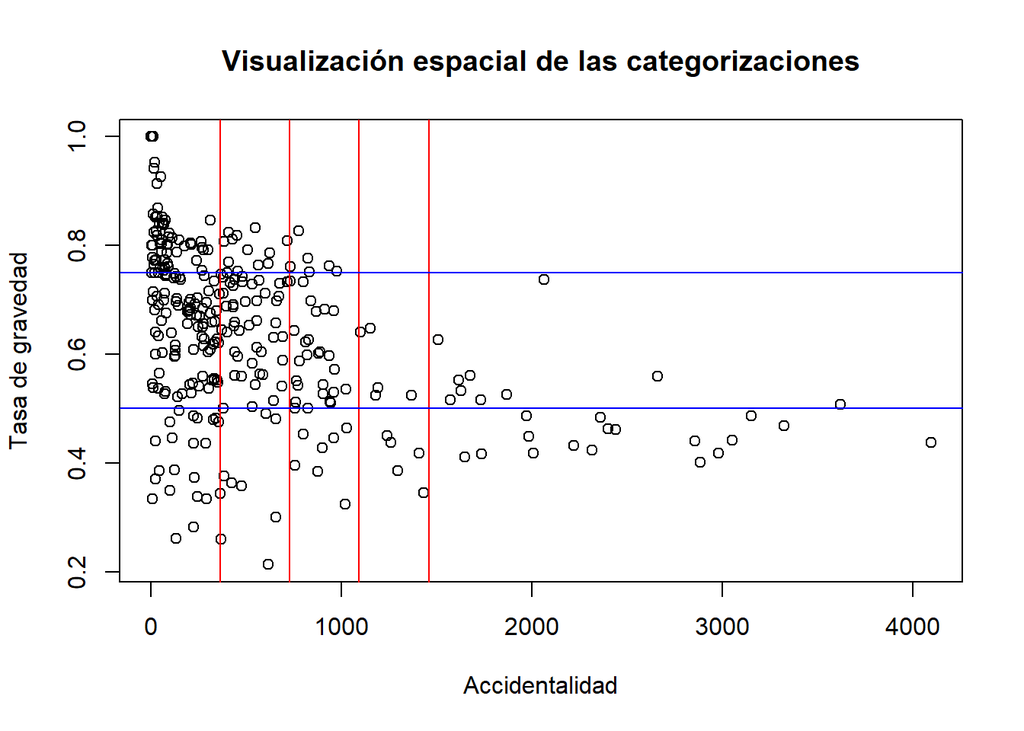

## Agrupamiento

El agrupamiento se define por grupo de riesgo, el cual es función de la categorización de accidentalidad y de la categorización de la tasa de gravedad, como se muestra a continuación:

$$Riesgo = f(No.\ de\ accidentes, tasa\ de\ gravedad)$$

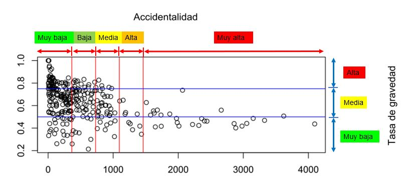

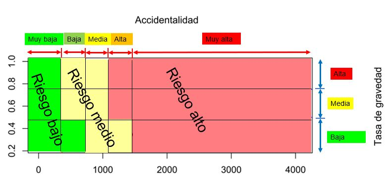

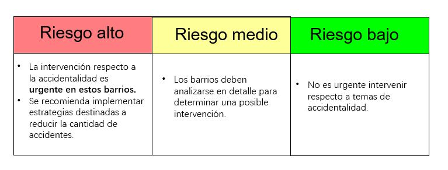

## Visualización de las agrupaciones

Con la metodología previa, la agrupación obtenida se visualiza de la siguiente forma.

Visualmente, se obtiene la siguiente agrupación:

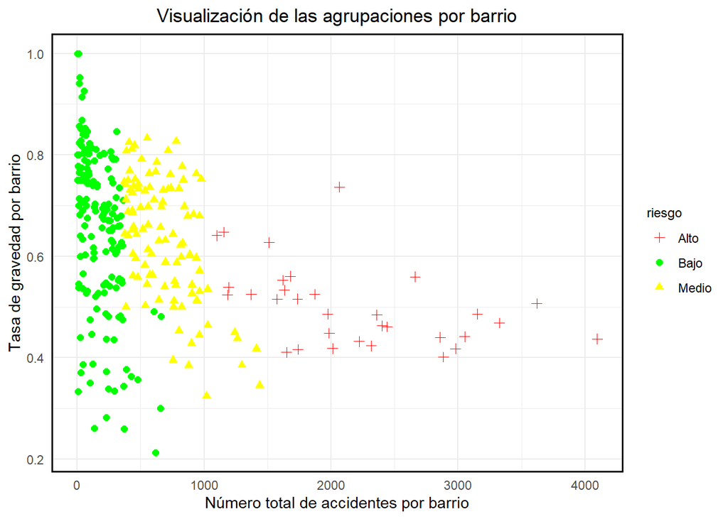

Tal agrupación, se visualiza en un mapa (el cual es presentado de manera interactiva en la App):

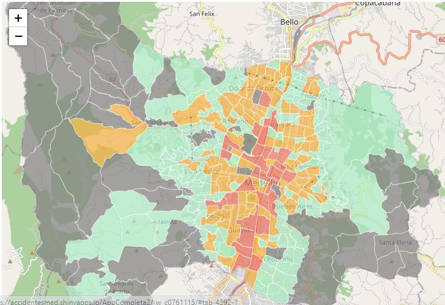

```r
#write.csv(df, "AgrupacionesPorBarrios_v01.csv", row.names = F)
```